# گزارش تمرین سوم کارآموزی حسابا

با خواندن داده شروع می‌کنیم و سپس بر اساس دوربین داشتن و سایز و … صفحه سعی می‌کنیم موبایل‌ها را از تبلت‌ها و ساعت‌های هوشمند جدا کنیم

```r
knitr::opts_chunk$set(warning = FALSE, message = FALSE)
library(dplyr)
```

```r
library(ggplot2)
data<-readRDS("~/Documents/HW3/mobile_data.rds")
data<-data%>%filter(!(year>=2012 & is.na(camera)))%>%filter(display_size<=6.9 & weight<300 & battery_mah<=5300)
```

# سوال ۱

نمودار ستونی ۲۰ شرکت برتر بر حسب تعداد گوشی تولید کرده

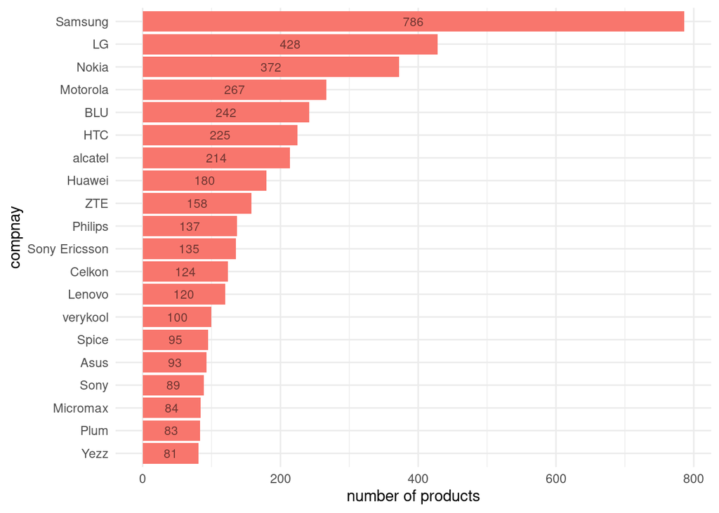

```r
companies<-data%>%
  group_by(company)%>%
  summarise(number_of_products=n())%>%
    arrange(-number_of_products)%>%head(20)

ggplot(data=companies,
       aes(number_of_products,reorder(company,number_of_products),fill="pink"))+
geom_col(show.legend = F)+
geom_text(aes(label = number_of_products,alpha=0.9),show.legend =FALSE,
          position = position_stack(vjust= 0.5),size=3)+
labs(y="compnay",x="number of products")+
theme_minimal()
```

# سوال ۲

```r
data_two<-data%>%
  group_by(year)%>%
  summarise(average_thickness=mean(dim_thickness,na.rm = T),
            average_breadth=mean(dim_breadth,na.rm = T),
            average_length=mean(dim_length,na.rm = T),
            average_camerapx=mean(cam_px,na.rm=T))
```

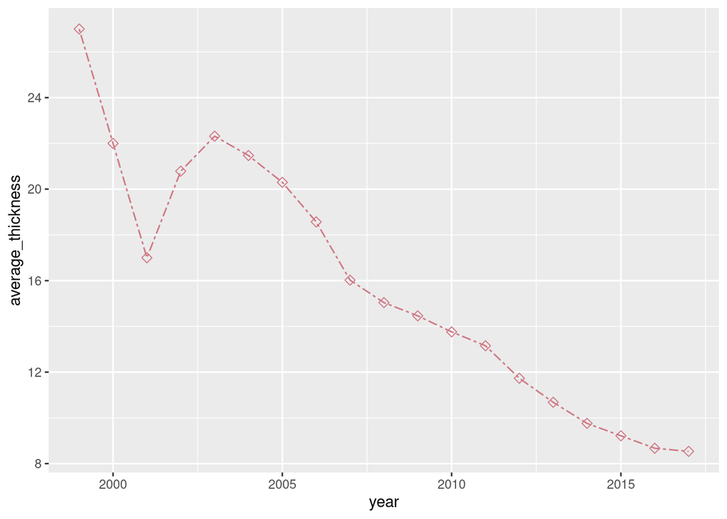

```r
ggplot(data=data_two,aes(x=year),show.legend = F)+
  geom_line(aes(y=average_thickness),color="#cf7985", linetype="twodash")+
  geom_point(aes(y=average_thickness),color="#cf7985",shape=5,size=2)
```

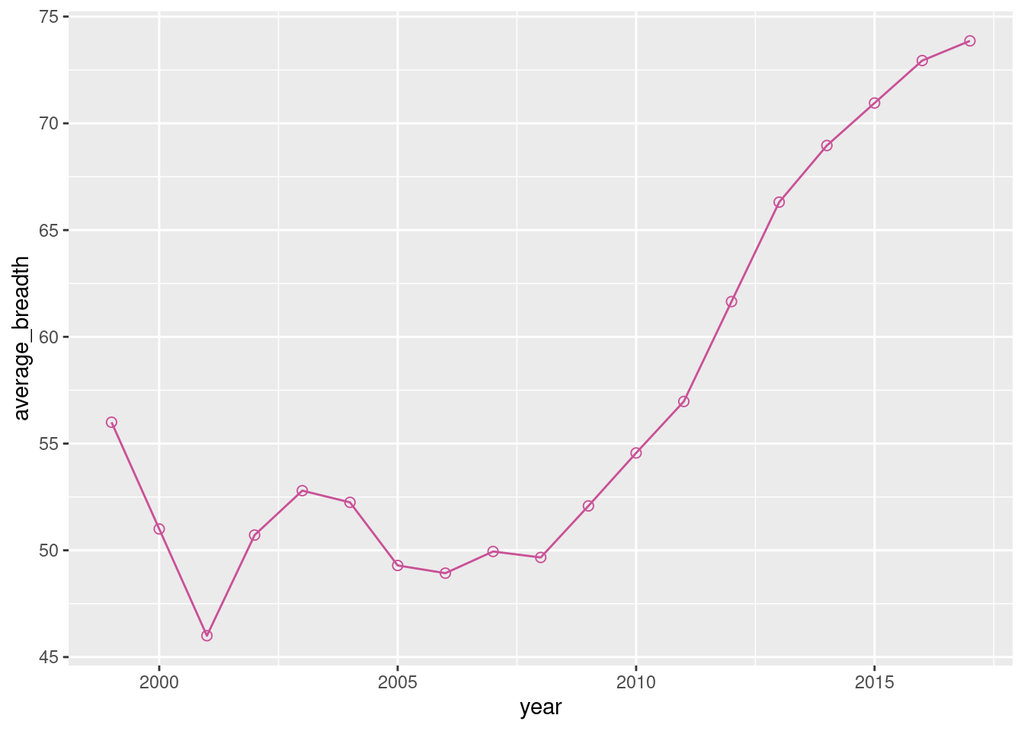

```r
ggplot(data=data_two,aes(x=year),show.legend = F)+
  geom_line(aes(y=average_breadth),color="#c95197", linetype="solid")+
  geom_point(aes(y=average_breadth),color="#c95197",shape=1,size=2)
```

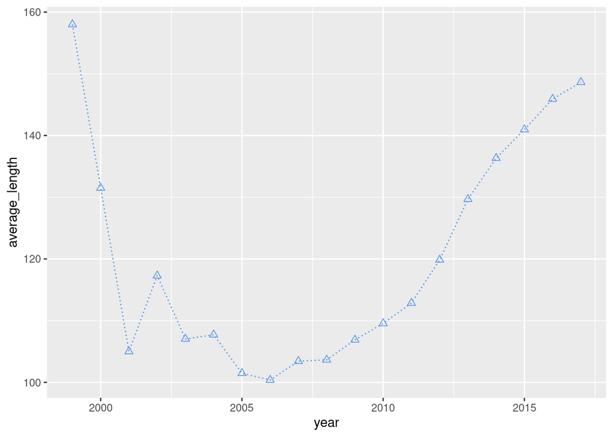

```r
ggplot(data=data_two,aes(x=year),show.legend = F)+
  geom_line(aes(y=average_length),color="#5e9be6", linetype="1212")+
  geom_point(aes(y=average_length),color="#5e9be6",shape= 2,size=2)
```

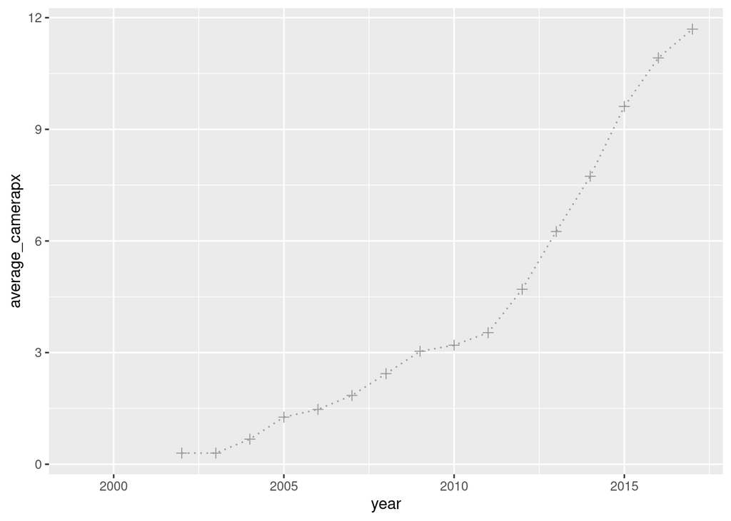

```r
ggplot(data=data_two,aes(x=year),show.legend = F)+
  geom_line(aes(y=average_camerapx),color="#999999", linetype="dotted")+
  geom_point(aes(y=average_camerapx),color="#999999",shape=3,size=2)
```

# سوال ۳

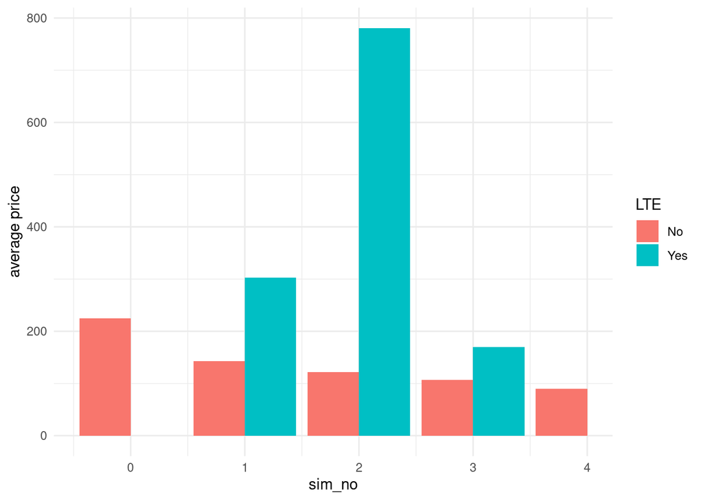

```r
data_three<-data%>%group_by(LTE,sim_no)%>%summarise(aprice=mean(price,na.rm = T))
ggplot(data=data_three,aes(sim_no,aprice,fill=LTE))+
  geom_col(position = position_dodge(preserve = "single"))+
  theme_minimal()+labs(y="average price")
```

# سوال ۴

همانطور که مشاهده می‌کنید با حذف جک هدفون، ضخامت گوشی‌ها کمتر شده

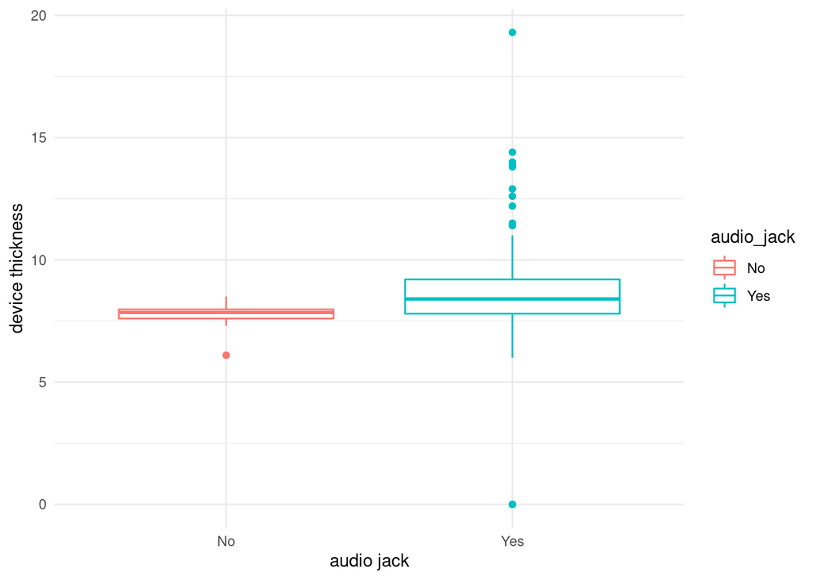

```r
data_four<-data%>%filter(year==2017)
ggplot(data=data_four)+
  geom_boxplot(aes(audio_jack,dim_thickness,group=audio_jack,color=audio_jack))+
  theme_minimal()+
  labs(
    x="audio jack",
    y="device thickness"
  )
```

# سوال ۵

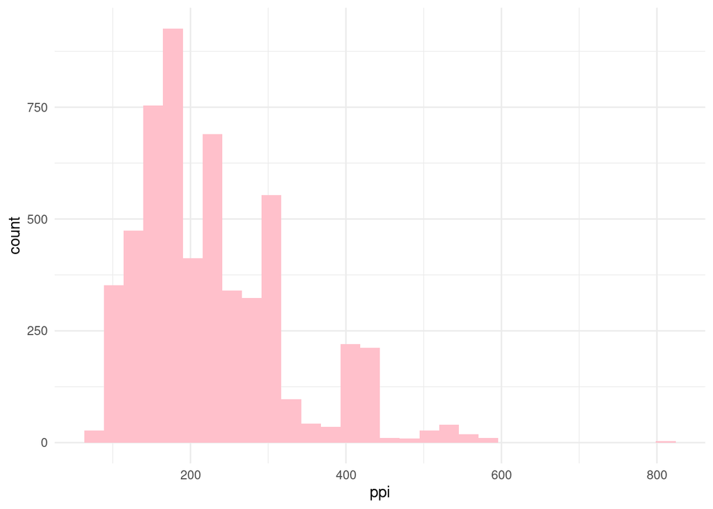

```r
PPI<-function(prow,pcol,diag){
  return(sqrt(prow**2+pcol**2)/diag)
}

data_five<-data%>%
  mutate(ppi=PPI(px_row,px_col,display_size))
ggplot(data=data_five,aes(x=ppi))+geom_histogram(fill="pink")+theme_minimal()
```

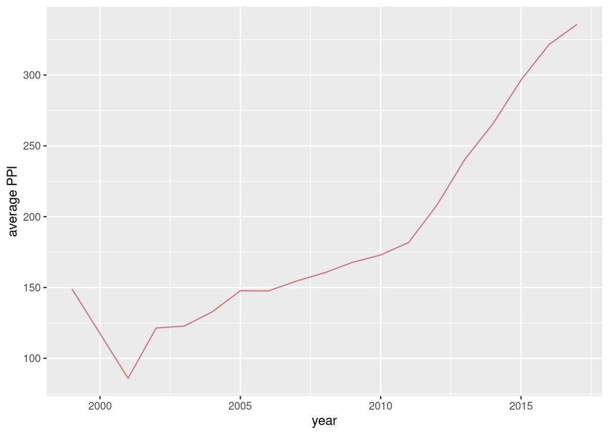

```r
data_five_sec<-data_five%>%group_by(year)%>%summarise(mean_ppi=mean(ppi,na.rm=T))
ggplot(data=data_five_sec,aes(x=year,y=mean_ppi))+geom_line(color="#cf7985")+labs(y="average PPI")
```

# سوال ۶

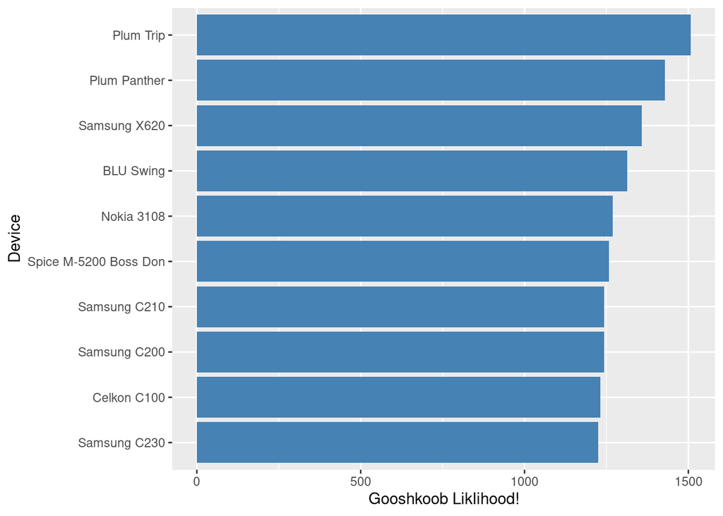

```r
data_six <-data%>%
  filter(dim_thickness > 15 & dim_length < 120 & dim_breadth < 50 & weight < 120)%>%
  mutate(gooshkoob_rate = dim_thickness * dim_length * dim_breadth / weight)%>%
  arrange(desc(gooshkoob_rate))%>%
  head(10)

ggplot(data_six,aes(x = reorder(paste(company,device, sep = " "),gooshkoob_rate), y = gooshkoob_rate))+
  geom_bar(stat = 'identity',fill="steelblue")+
  coord_flip()+
  labs(x='Device',y="Gooshkoob Liklihood!")
```

# سوال ۷

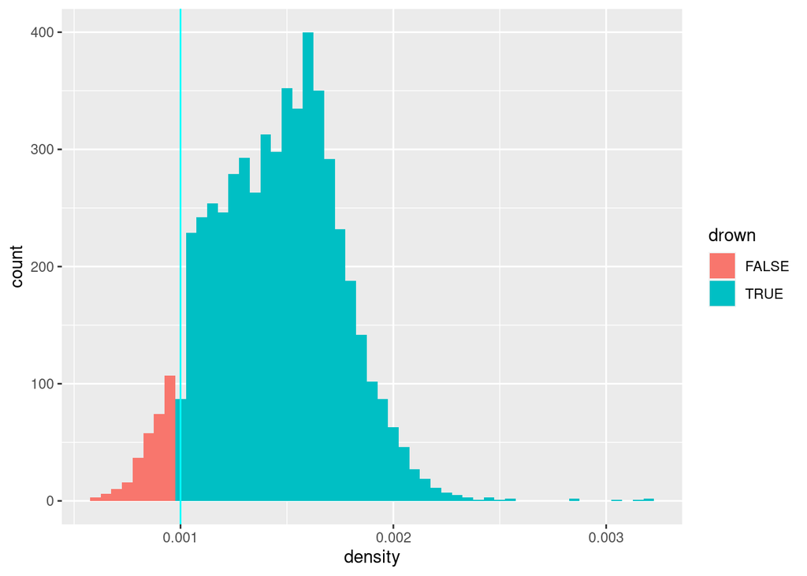

```r
library(magick)
library(ggpattern)
data_seven<-data%>%
  mutate(density=weight/(dim_length*dim_breadth*dim_thickness),drown=if_else(density<0.001,FALSE,TRUE))%>%arrange(density)

ggplot(data_seven, aes(x=density)) +
geom_histogram(aes(fill=drown), position="identity", alpha=1,binwidth = 0.00005)+
  geom_vline(xintercept = 0.001,color="cyan")
```

# سوال ۸

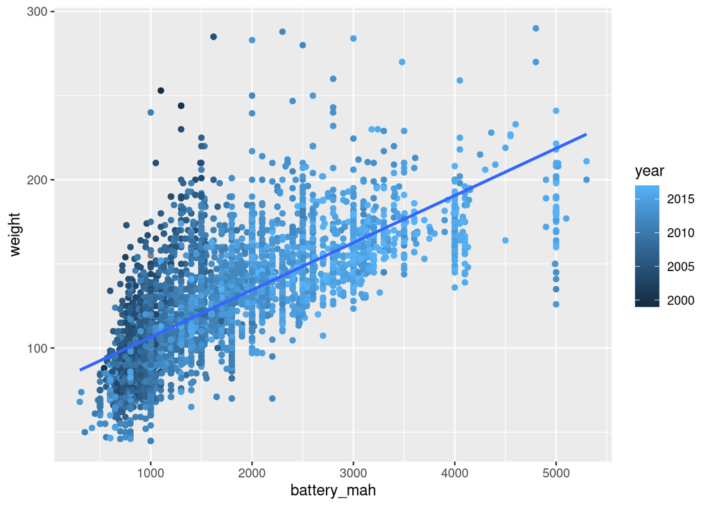

```r
library(tidyverse)
data_eight <-data%>%
  drop_na(weight,battery_mah)

ggplot(data,aes(x=battery_mah,y=weight, color=year))+
  geom_point()+
  geom_smooth(method='lm', se=FALSE)
```

```r
print(paste("correlation:",round(cor(data_eight$battery_mah,data_eight$weight),2)))
```

```
## [1] "correlation: 0.74"
```

# سوال ۹

نمودار تغییر قیمت سری های برند سامسونگ در طول زمان

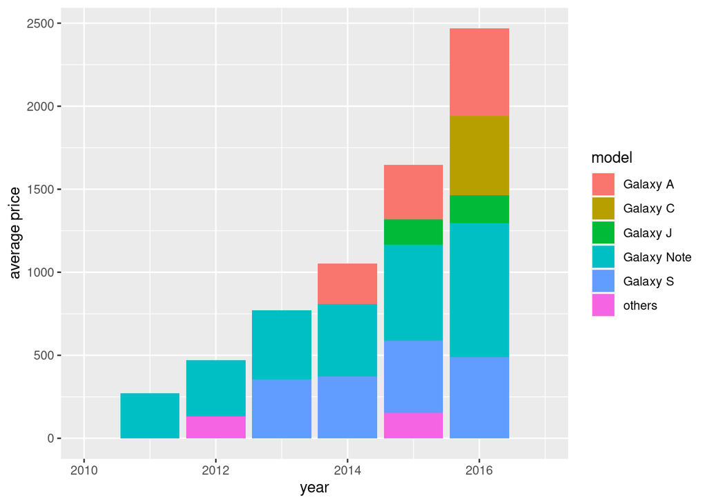

```r
library(stringr)
samsung<-data%>%filter(company=='Samsung')
samsung_models<-samsung%>%mutate(model=case_when(
  str_detect(device,"Galaxy A\\d")~"Galaxy A",
  str_detect(device,"Galaxy J\\d")~"Galaxy J",
  str_detect(device,"Galaxy C\\d")~"Galaxy C",
  str_detect(device,"Galaxy S\\d")~"Galaxy S",
  str_detect(device,"Note")~"Galaxy Note",
  TRUE~"others"))%>%group_by(year,model)%>%summarise(average_price=mean(price,rm.na=T))
ggplot(samsung_models,aes(x=year,y=average_price,fill=model))+
  geom_col()+labs(y="average price")+xlim(2010,2017)
```

# سوال ۱۰

اگر میزان تولید هر شرکت در سال‌ها را در نظر بگیریم به نمودار زیر میرسیم این نمودار نشان میدهد که بعضی از شرکت‌ها همیشه در صحنه‌ی تولید گوشی موبایل بودند و به تولیدات خود ادامه می‌دهند اما قسمت پایین نمودار نشان می‌دهد که بسیاری از شرکت ها بعد از ظهور و چند سالی تولید از رقابت کنار می‌روند.

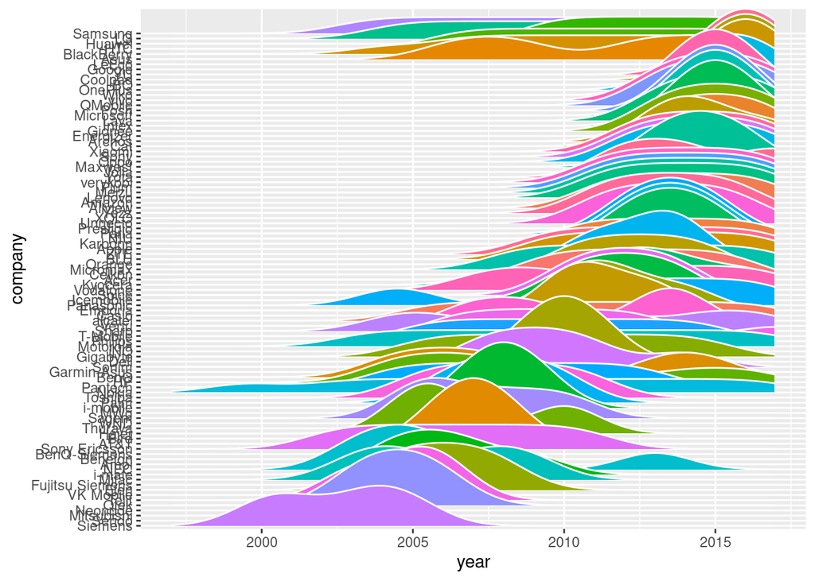

```r
library(ggridges)
data_ten<-data%>%
  group_by(year,company)%>%
  summarise()
ggplot(data_ten, aes(x = year, y = reorder(company,year),fill=company, group = company))+
  geom_density_ridges(scale = 10, size = 0.5,
                      show.legend=F,color="white") +labs(y="company")+xlim(1997,2017)
```